# Predict 401 Quick Start Guide, Solutions

### 15 Graphics

#### Exercises

1. Use the dataset “faithful” and create a scatterplot of the variables.

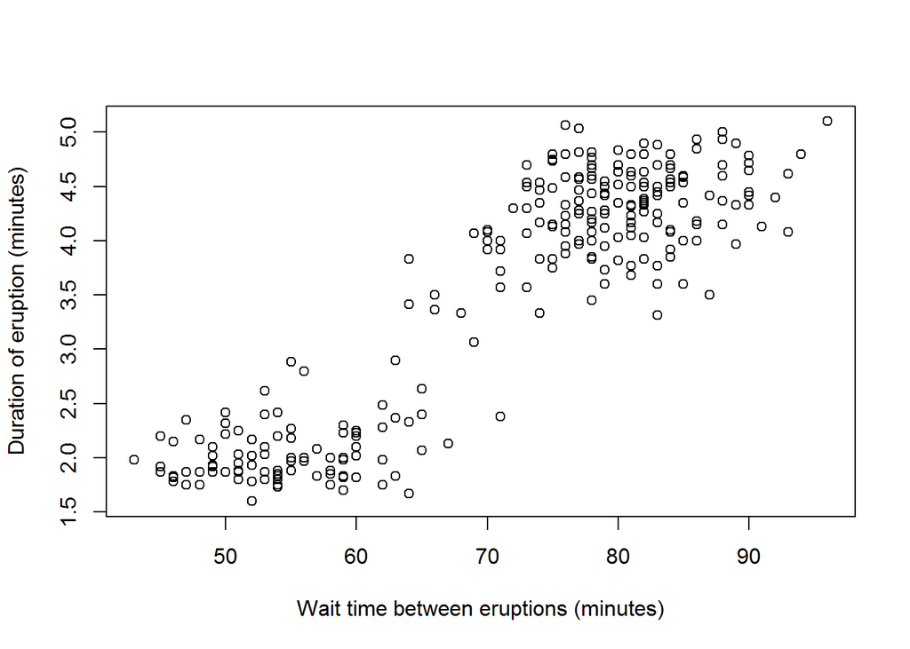

```r
data(faithful)
plot(faithful$waiting, faithful$eruptions,
     xlab = "Wait time between eruptions (minutes)",
     ylab = "Duration of eruption (minutes)")
```

2. Use *x <- rnorm(250)* to generate 250 standard random values. Produce a histogram and compare to a stem-and-leaf plot of the data. The function *stem()* will produce the stem-and-leaf plot.

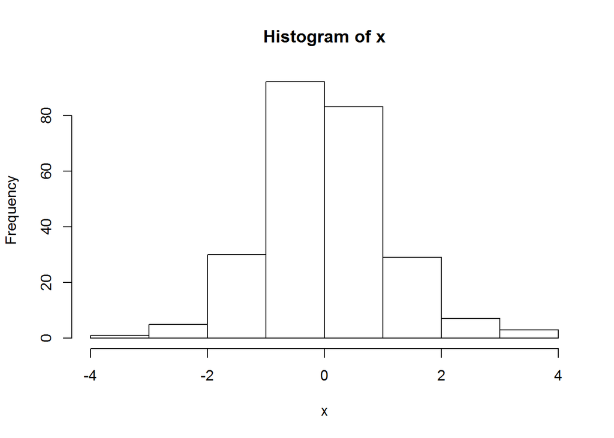

```r
x <- rnorm(n = 250, mean = 0, sd = 1)

hist(x)
```

```r
stem(x)
```

```
##
##   The decimal point is at the |
##
##   -3 | 2
##   -2 | 7
##   -2 | 220000
##   -1 | 977666
##   -1 | 444443333222222211100000
##   -0 | 9999988888887777777766666666665555555555
##   -0 | 44444444444444443333333333333222222222111111100000
##    0 | 0011111111112222333333333344444444444
##    0 | 55555555566666666667777777777777888889999999
##    1 | 00000111222223333444
##    1 | 55666667778
##    2 | 00012
##    2 | 57
##    3 | 112
```

### 16 Color Applications

#### Exercises

1. Use RColorBrewer and six colors from the Accent scheme to produce a pie chart with equal area slices. This will require use of *brewer.pal()*.

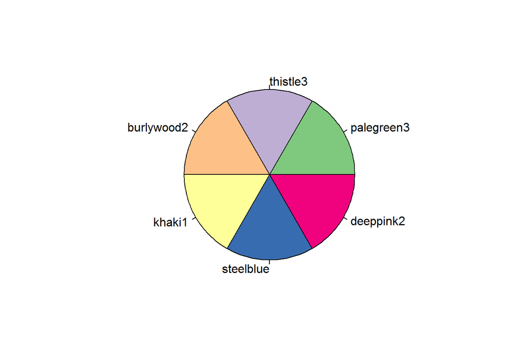

```r
library(RColorBrewer)
library(plotrix)
pie(rep(1, 6), labels = sapply(brewer.pal(n = 6, name = "Accent"), color.id),
    col = brewer.pal(n = 6, name = "Accent"))
```

2. Use *set.seed(123)* and *rnorm(n = 100, mean = 100, sd = 1.5)* to generate six random samples. Use the color scheme from (1) above to produce six side-by-side boxplots.

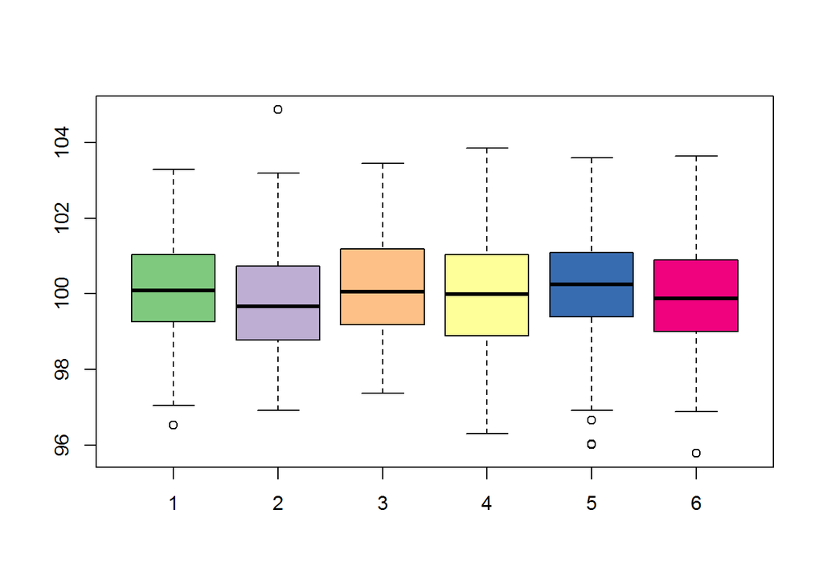

```r
set.seed(123)
results <- replicate(6, rnorm(n = 100, mean = 100, sd = 1.5))
boxplot(results, col = brewer.pal(n = 6, name = "Accent"))
```

3. Produce six histograms using the samples from (2). Color each with a different color from the *palette(c(“red”, “purple”, “blue”, “green3”, “yellow”, “orange”))*.

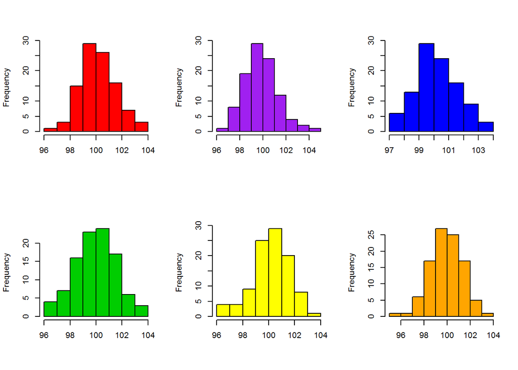

```r
palette(c("red", "purple", "blue", "green3", "yellow", "orange"))

par(mfrow = c(2, 3))
for (i in 1:6) {
  hist(results[, i],
       col = palette()[i],
       xlab = "",
       main = "")
}
```

```r
par(mfrow = c(1, 1))
```

4. Use *col2rgb()* and determine the *rgb()* representation for the six colors in the palette used in (3) above. Convert the rgb codes into hex codes.

```r
color.mat <- col2rgb(palette())

colorID <- function(red, green, blue, max) {
    object <- rgb(red, green, blue, maxColorValue = max)
    return(object)
}

color.list <- c(NULL)

# Build color list
for (k in 1:6) {
    item <- colorID(color.mat[1, k], color.mat[2, k], color.mat[3, k], 255)
    color.list <- c(color.list, item)
}

color.list # [1] "#FF0000" "#A020F0" "#0000FF" "#00CD00" "#FFFF00" "#FFA500"
```

```
## [1] "#FF0000" "#A020F0" "#0000FF" "#00CD00" "#FFFF00" "#FFA500"
```